# Scientific Question: Can the structure of the hydrolyses in the egg whites of turtles, chickens, and turkeys, show the effects of evolution?

The proteins that are being surveyed are hydrolyses in the egg whites of turtles, chickens, and turkeys. Hydrolase is a class of enzyme that commonly perform as biochemical catalysts that use water to break a chemical bond. There are two types of hydrolyses that are being surveyed, lysozyme and ribonuclease. Lysozyme hydrolyses the β-1,4-glycosidic bond between N-acetylmuramic acid and N-acetylglucosamine of peptidoglycan, the structural component of the bacterial cell walls. Ribonucleases catalyze both the in vivo and in vitro degradation of ribonucleic acid (RNA) molecules into smaller components.

The structure of these protein can be obtained from the PDB website:

- 1TEW: https://www.rcsb.org/structure/1TEW
- 6LYZ: https://www.rcsb.org/structure/6LYZ
- 2GV0: https://www.rcsb.org/structure/2GV0
- 2ZPO: https://www.rcsb.org/structure/2ZPO

The WNT gene was discovered to signal the carapace development in turtles. The WNT gene is one of the conserved genes between turtles, chickens, and turkeys. It was also discovered that turtles are closely related to the bird-crocodilian lineage. WNT genes regulate cell growth, function, differentiation, and cell death, therefore the WNT genes play a central role in bone development, modeling, and remodeling.

The structure of these genes can obtained from the NCBI nucleotide database:

- Chelonia mydas WNT3A: https://www.ncbi.nlm.nih.gov/nuccore/XM_037891248.2
- Chelonia mydas WNT5A: https://www.ncbi.nlm.nih.gov/nuccore/XM_037904882.2
- Chelonia mydas WNT8A: https://www.ncbi.nlm.nih.gov/nuccore/XM_007053596.4
- Pelodiscus sinensis WNT3A: https://www.ncbi.nlm.nih.gov/nuccore/XM_014576849.2
- Pelodiscus sinensis WNT5A: https://www.ncbi.nlm.nih.gov/nuccore/XM_006129743.3
- Pelodiscus sinensis WNT8A: https://www.ncbi.nlm.nih.gov/nuccore/XM_014569982.2
- Gallus gallus WNT3A: https://www.ncbi.nlm.nih.gov/nuccore/NM_001171601.3
- Gallus gallus WNT5A: https://www.ncbi.nlm.nih.gov/nuccore/NM_001396502.1
- Gallus gallus WNT8A: https://www.ncbi.nlm.nih.gov/nuccore/NM_205531.2
- Meleagris gallopavo WNT3A: https://www.ncbi.nlm.nih.gov/nuccore/XM_019616734.2
- Meleagris gallopavo WNT5A: https://www.ncbi.nlm.nih.gov/nuccore/XM_019620083.2
- Meleagris gallopavo WNT8A: https://www.ncbi.nlm.nih.gov/nuccore/XM_031555716.1

# Hypothesis: If the protein structure of the hydrolase in the egg whites of turtles, chickens, and turkeys shows the effects of evolution, then there is a conserved region in their protein sequence.

To answer the question and hypothese, the WNT genes were downloaded from the NCBI nucleotide database, in fasta format, and the egg white hydrolase proteins were downloaded from the PDB website, in pdb and fasta format.

Multiple sequence alignment was the necessary first step, because one cannot go further without knowing the similarities between each sequence. A phylogenetic tree was made with the WNT genes, to ensure that the aligments are correct, and to show how each species diverge. Then the PDB structures of the hydrolase proteins were used to look at the structure and compare. Finally, sequence logo was used to see whether there are conserved regions between these hydrolase protein, that would show the effects of evolution.

### Packages

- MAFFT: A multiple alignment subpackage of Bio.Align, a package used for sequence alignments. It can be used for either nucleotide or amino acid sequences. The file of the query sequence can be any format (fasta, aln, clustal, etc.) To learn more about MAFFT, see: https://biopython.org/docs/1.76/api/Bio.Align.Applications.html
- logomaker: A package for generating publication-quality sequence logos. It can generate logos that shows properties of DNA, RNA, or protein sequences. The logos generated can either be the default or it can be customaized to ones' preferences. One of the many ways to customize is by choosing the color scheme. They have a set of color scheme to choose from, but it can also be customized to one's choosing. To learn more about logomaker, see: https://logomaker.readthedocs.io/en/latest/
- weblogo: A package for generating sequence logos. Supported file formats include CLUSTALW, FASTA, plain flatfile, MSF, NBRF, PIR, NEXUS and PHYLIP for multiple sequence alignments, and transfac for position weight matrices. Wenlogo can also access online, it is not just a sequence logo package for python. To learn more about weblogo, see: http://weblogo.threeplusone.com/
- pandas: A package that is an open source Python package that is most widely used for data science/data analysis and machine learning tasks. It is a package that is built on top of Numpy, which is another package. It can be used to explore, clean, and process data. Pandas uses tabular data. To learn more about pandas, see: https://www.activestate.com/resources/quick-reads/what-is-pandas-in-python-everything-you-need-to-know/
- numpy: A package that provided support for multi-dimensional arrays. Numpy stands for Numerical Python. It also has functions for working in domain of linear algebra, fourier transform, and matrices. It supplies an enormous library of high-level mathematical functions that operate on these arrays and matrices. To learn more about numpy, see: https://numpy.org/doc/stable/user/absolute_beginners.html
- matplotlib: A package that contains a comprehensive library for creating static, animated, and interactive visualizations in Python. It can be sued to customize visual style and layout. There are also many tools built into the package that can be used for plotting interfaces. To learn more about matplotlib, see: https://matplotlib.org
- py3dmol: A package for molecular visualization. The visial library, 3DMol.js is included in the package, therefore it is a convenient package for structural information. There are many features included in the package, such as support for PDB files, SDF files, etc. The molecular style of the 3D structure can also be changed in this package. To learn more about py3Dmol, see: https://www.blopig.com/blog/tag/py3dmol/
- nglview: A package used to interactively viw molecular structures and trajectories. To learn more about nglviewer, see: https://academic.oup.com/bioinformatics/article/34/7/1241/4721781

```python
conda install -c bioconda mafft
```

```
Solving environment: done

# All requested packages already installed.
```

```python
conda install -c conda-forge py3dmol
```

```
Solving environment: done

# All requested packages already installed.
```

```python
pip install logomaker
```

```python
pip install weblogo
```

```python
from Bio.Align.Applications import MafftCommandline
```

```python
import Bio
from Bio import SeqIO
from Bio import Phylo, AlignIO
from Bio.Phylo.TreeConstruction import DistanceCalculator, DistanceTreeConstructor
import matplotlib
import matplotlib.pyplot as plt
from Bio.PDB import *
import nglview as nv
import py3Dmol
import weblogo.seq_io.fasta_io
import logomaker as lm
import numpy as np
import pandas as pd
import matplotlib.pyplot as plt

# displays logos inline within the notebook;
# remove if using a python interpreter instead
%matplotlib inline
```

# Multiple Sequence Alignment

```python
#loading query nucleotide sequence as the input file for alignment
in_file = "final_seq.txt"

#assign commandline to global variable
mafft_cline = MafftCommandline(input=in_file)

#ensure that the variable is assigned properly
print(mafft_cline)
```

```
mafft final_seq.txt
```

```python
#constuct stdout, and stderr object using Mafftcommandline
#stdout = standard output
stdout, stderr = mafft_cline()
```

```python
#assign a file name for the output aligned sequence (stdout)
with open("aligned.fasta", "w") as handle:
    handle.write(stdout)

#parse the output "aligned.fasta"
align = AlignIO.read("aligned.fasta", "fasta")

#print the aligned nucleotide sequence
print(align)
```

```
Alignment with 12 rows and 1359 columns
--------------------------------------------...taa lcl|PS3A
atgggtctcgtctggaagcagctcccaaaatggcccataaagaa...tag lcl|PS5A
------------------------------------atgaaga-...taa lcl|PS8A
--------------------------------------------...taa lcl|CM3A
------------------------------------atggagaa...tag lcl|CM5A
------------------------------------atgaaga-...taa lcl|CM8A
--------------------------------------------...taa lcl|GG3A
------------------------------------atggagaa...tag lcl|GG5A
------------------------------------atgaggg-...tag lcl|GG8A
--------------------------------------------...taa lcl|MG3A
--------------------------------------------...tag lcl|MG5A
------------------------------------atgaggg-...tag lcl|MG8A
```

# Phylogenetic Clustering

```python
#read aligned sequences from the file 'aligned.fasta', outputted from the query sequence 'final_seq.txt'
aligned = AlignIO.read('aligned.fasta', "fasta")
```

```python
#construct a Distancecalculator object
calculator = DistanceCalculator('identity')

#calculate the distance matrix
distMatrix = calculator.get_distance(aligned)
```

```python
#prints out distance matrux results
print(distMatrix)
```

```
lcl|PS3A	0
lcl|PS5A	0.48050036791758644	0
lcl|PS8A	0.48123620309050774	0.5901398086828551	0
lcl|CM3A	0.050772626931567366	0.48565121412803536	0.49080206033848417	0
lcl|CM5A	0.45253863134657835	0.06622516556291391	0.5665930831493746	0.45842531272994846	0
lcl|CM8A	0.4782928623988226	0.5879323031640913	0.05150846210448856	0.48933038999264167	0.5636497424576894	0
lcl|GG3A	0.0934510669610007	0.48050036791758644	0.48344370860927155	0.08462104488594557	0.45180279617365715	0.47976453274466524	0
lcl|GG5A	0.47755702722590143	0.1589403973509934	0.5974981604120677	0.48344370860927155	0.11994113318616628	0.5952906548933039	0.48050036791758644	0
lcl|GG8A	0.4650478292862399	0.5886681383370125	0.1574687270051508	0.4724061810154525	0.5570272259013981	0.1589403973509934	0.47755702722590143	0.5835172921265637	0
lcl|MG3A	0.14054451802796175	0.5003679175864606	0.4687270051508462	0.13318616629874913	0.4738778513612951	0.4665194996320824	0.06622516556291391	0.5011037527593819	0.4606328182487123	0
lcl|MG5A	0.4069168506254599	0.17071376011773365	0.5423105224429727	0.4142752023546725	0.13539367181751283	0.5393671817512877	0.4105960264900662	0.08241353936718177	0.5298013245033113	0.4311994113318617	0
lcl|MG8A	0.4657836644591612	0.5864606328182487	0.1537895511405445	0.4753495217071376	0.5555555555555556	0.1596762325239146	0.4738778513612951	0.5842531272994849	0.032376747608535705	0.45842531272994846	0.5283296541574687	0
	lcl|PS3A	lcl|PS5A	lcl|PS8A	lcl|CM3A	lcl|CM5A	lcl|CM8A	lcl|GG3A	lcl|GG5A	lcl|GG8A	lcl|MG3A	lcl|MG5A	lcl|MG8A
```

```python
#create a DistanceTreeConstructor object
constructor = DistanceTreeConstructor()

#constrcut phylogenetic tree using UPGMA
#UPGMA is  a simple agglomerative (bottom-up) hierarchical clustering method
Tree = constructor.upgma(distMatrix)
```

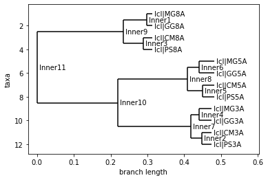

```python
#draws the phylogenetic tree
Phylo.draw(Tree)
```

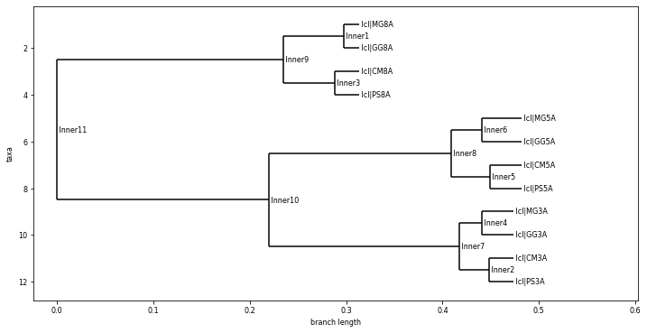

```python
#adjust size of phylogenetic tree

#changes font size
matplotlib.rc('font', size = 8)

#adjust figure size, so that it is bigger
plt.figure(figsize = (12,6))

#add an axes to the current figure and make it the current axes
axes = plt.axes()
Phylo.draw(Tree, axes = axes)
```

# Structural Bioinformatics

```python
#Parse a PDB file and return as a global variable
parser = PDBParser()
```

```python
#STRUCTURE OF HEXAGONAL TURKEY EGG WHITE LYSOZYME AT 1.65 ANGSTROMS RESOLUTION

#collects the protein structure of 1TEW from PDB
view = py3Dmol.view(query='pdb:1TEW')

#sets the style and color scheme of the protein strcuture
view.setStyle({'cartoon':{'color':'spectrum'}})

#shows the protein strcuture
view
```

```
<py3Dmol.view at 0x7fb97903ddf0>
```

```python
#Real-space refinement of the structure of hen egg-white lysozyme

#collects the protein structure of 6LYZ from PDB
view = py3Dmol.view(query='pdb:6LYZ')

#sets the style and color scheme of the protein strcuture
view.setStyle({'cartoon':{'color':'spectrum'}})

#shows the protein strcuture
view
```

```
<py3Dmol.view at 0x7fb978ea2b50>
```

```python
#Crystal Structure of Green Turtle Egg White Ribonuclease

#collects the protein structure of 2ZPO from PDB
view = py3Dmol.view(query='pdb:2ZPO')

#sets the style and color scheme of the protein strcuture
view.setStyle({'cartoon':{'color':'spectrum'}})

#shows the protein strcuture
view
```

```
<py3Dmol.view at 0x7fb979028b50>
```

```python
#The structure of the orthorhombic form of soft-shelled turtle lysozyme at 1.9 angstroms resolution

#collects the protein structure of 2GV0 from PDB
view = py3Dmol.view(query='pdb:2GV0')

#sets the style and color scheme of the protein strcuture
view.setStyle({'cartoon':{'color':'spectrum'}})

#shows the protein strcuture
view
```

```
<py3Dmol.view at 0x7fb979028370>
```

# Sequence Logo

```python
#loading query protein sequence as the input file for alignment
in_file = "protein_seq.txt"

#assign commandline to global variable
mafft_cline_protein = MafftCommandline(input=in_file)

#ensure that the variable is assigned properly
print(mafft_cline_protein)
```

```
mafft protein_seq.txt
```

```python
#constuct stdout, and stderr object using Mafftcommandline
#stdout = standard output
stdout_protein, stderr_protein = mafft_cline_protein()
```

```python
#assign a file name for the output aligned sequence (stdout)
with open("protein.fasta", "w") as handle:
    handle.write(stdout_protein)

#parse the output "protein.fasta"
align_protein = AlignIO.read("protein.fasta", "fasta")

#prints the aligned protein sequence
print(align_protein)
```

```
Alignment with 4 rows and 156 columns
-KVYGRCELAAAMKRL----------------GLDNYRGYSLGN...CRL 1TEW_1|Chain
-KVFGRCELAAAMKRH----------------GLDNYRGYSLGN...CRL 6LYZ_1|Chain
-----ETRYEKFLRQHVDYPRTAAPDTRTYCNQMMQRRGMTLP-...I-- 2ZPO_1|Chain
GKIYEQCELAREFKRH----------------GMDGYHGYSLGD...CKL 2GV0_1|Chain
```

```python
#load raw protien sequence file
afile = open("protein.fasta")

#read a file of sequence data and return a SeqList
seqs = weblogo.seq_io.fasta_io.read(afile)

#preview sequence
print(seqs)
```

```
['-KVYGRCELAAAMKRL----------------GLDNYRGYSLGNWVCAAKFESNF-NTHATNRNT-DGSTDYGILQINSRWWCNDGRTPGSKNLCNIPCSALLSSDITAS---VNC-----AKKIASGGNGMNAWVAWRNRCKGTDVHAWIRGCRL', '-KVFGRCELAAAMKRH----------------GLDNYRGYSLGNWVCAAKFESNF-NTQATNRNT-DGSTDYGILQINSRWWCNDGRTPGSRNLCNIPCSALLSSDITAS---VNC-----AKKIVSDGNGMNAWVAW…
```

```python
#creates counts matrix
ww_counts_df = lm.alignment_to_matrix(sequences=seqs, to_type='counts', characters_to_ignore='.-X')
```

```python
#preview counts dataframe, first 5 rows
ww_counts_df.head()
```

| pos | A | C | D | E | F | G | H | I | K | L | M | N | P | Q | R | S | T | V | W | Y |
| --- | --- | --- | --- | --- | --- | --- | --- | --- | --- | --- | --- | --- | --- | --- | --- | --- | --- | --- | --- | --- |
| 0 | 0.0 | 0.0 | 0.0 | 0.0 | 0.0 | 1.0 | 0.0 | 0.0 | 0.0 | 0.0 | 0.0 | 0.0 | 0.0 | 0.0 | 0.0 | 0.0 | 0.0 | 0.0 | 0.0 | 0.0 |
| 1 | 0.0 | 0.0 | 0.0 | 0.0 | 0.0 | 0.0 | 0.0 | 0.0 | 3.0 | 0.0 | 0.0 | 0.0 | 0.0 | 0.0 | 0.0 | 0.0 | 0.0 | 0.0 | 0.0 | 0.0 |
| 2 | 0.0 | 0.0 | 0.0 | 0.0 | 0.0 | 0.0 | 0.0 | 1.0 | 0.0 | 0.0 | 0.0 | 0.0 | 0.0 | 0.0 | 0.0 | 0.0 | 0.0 | 2.0 | 0.0 | 0.0 |
| 3 | 0.0 | 0.0 | 0.0 | 0.0 | 1.0 | 0.0 | 0.0 | 0.0 | 0.0 | 0.0 | 0.0 | 0.0 | 0.0 | 0.0 | 0.0 | 0.0 | 0.0 | 0.0 | 0.0 | 2.0 |
| 4 | 0.0 | 0.0 | 0.0 | 1.0 | 0.0 | 2.0 | 0.0 | 0.0 | 0.0 | 0.0 | 0.0 | 0.0 | 0.0 | 0.0 | 0.0 | 0.0 | 0.0 | 0.0 | 0.0 | 0.0 |

```
<logomaker.src.Logo.Logo at 0x7fb9791eb100>
```

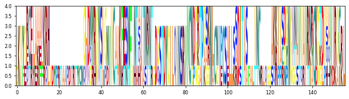

```python
#show sequence logo with color scheme "skylign_protein"
lm.Logo(ww_counts_df, color_scheme='skylign_protein')
```

# Analysis of results